# TMA4320 Vitenskapelig beregning, prosjekt 1

## Diffusjonssimulering

### Mikael Bourmistrov, Denis Lobe, Ivar Sandvik

## Oppgave 1:

### a) Analytisk løsning av differensialligningen

$$ \frac{\partial\varphi(x, t)}{\partial t} = D \frac{\partial^2\varphi}{\partial x^2}, \qquad D = \frac{(\Delta x)^2}{2\Delta t} $$

La $\varphi$ være standard normalfordeling definert som $\varphi = \frac{1}{\sigma\sqrt{2\pi}}e^{-\frac{x^2}{2\sigma^2}}$ med $\sigma^2=at$ slik at $\varphi(x, t) = \frac{e^{-\frac{x^2}{2at}}}{\sqrt{2\pi at}}$. Vi kan se at $\varphi$ løser den partielle differensialligningen ved å finne $\frac{\partial\varphi}{\partial t}$, $D \frac{\partial^2\varphi}{\partial x^2}$, sette høyre og venstre side lik hverandre for så å løse for $a$:

$$ \frac{\partial\varphi}{\partial t} = \frac{ \frac{\partial}{\partial t}\left(e^{-\frac{x^2}{2at}} \right)\sqrt{2\pi at} - \frac{\partial}{\partial t} \left(\sqrt{2\pi at} \right)e^{-\frac{x^2}{2at}} } {\left(\sqrt{2\pi at}\right)^2 } = \frac{\frac{x^2e^{-\frac{x^2}{2at}}}{2at^2}\sqrt{2\pi at} - \frac{\sqrt{\pi a}}{\sqrt{2t}}e^{-\frac{x^2}{2at}}} {2\pi at} = \frac{e^{-\frac{x^2}{2at}}\left(x^2-at\right)} {2\sqrt{2\pi}a^{3/2}t^{5/2}}, $$

og

$$ \frac{\partial^2\varphi}{\partial x^2} = \frac{\partial}{\partial x} \left(-\frac{e^{-\frac{x^2}{2at}}x}{\sqrt{2\pi} \sqrt[3]{a^2t^2}}\right) = \frac{1} {{\sqrt{2\pi} \sqrt[3]{a^2t^2}}} \left( \frac{\partial}{\partial x} \bigl(e^{-\frac{x^2}{2at}}\bigr)x - \frac{\partial x}{\partial x}e^{-\frac{x^2}{2at}} \right) = \frac{e^{-\frac{x^2}{2at}} \left(x^2-at \right)} {\sqrt{2\pi}\;a^{5/2}t^{5/2}}.$$

La $Q = \frac{e^{-\frac{x^2}{2at}} \left(x^2-at \right)} {\sqrt{2\pi} \; t^{5/2}}, $ da er

$$ \frac{\partial\varphi}{\partial t} = \frac{Q}{2a^{3/2}} = D \frac{Q}{a^{5/2}} = D \frac{\partial^2\varphi}{\partial x^2} \quad \Leftrightarrow \quad \def\doubleunderline#1{\underline{\underline{#1}}}\doubleunderline{a = 2D} $$

for $\Delta x=1$ og $\Delta t=1$ er $D = \frac{(\Delta x)^2}{2\Delta t} = \frac{1}{2} \quad \Rightarrow \quad a = 1$

### b) En én-dimensjonal virrevandrer

```python
import numpy as np
import matplotlib.pyplot as plt
import time
```

```python
def en_endimensjonal_vandrer(M, p_r, Dx):
    x = np.zeros(M+1)
    t = np.linspace(0, M, M+1)          # En vektor som inkluderer alle tidstegene virrevandreren tar

    random = np.random.uniform(0, 1, M) # lager en pseudorandom array med M elementer, den skal vi videre bruke for å avgjøre om en vandrer skal vandre til venstre eller høyre per tidssteg. Verdiene produsert varier melllom 0 og 1.
    for i in range(M):                  # Itererer for hvert tiddsteg
        if random[i] < p_r:             # Denne tilfeldige checken ser om en vandrer går venstre eller høyre (positiv x-verdi er til høyre)
            x[i+1] = x[i] + Dx
        else:
            x[i+1] = x[i] - Dx

    return x, t
```

[output not shown]

### c) Plot av koden over

```
Sluttposisjon til vandrer med p_r 0.45 : -9546.0
Sluttposisjon til vandrer med p_r 0.5 : -110.0
Sluttposisjon til vandrer med p_r 0.55 : 9656.0
```

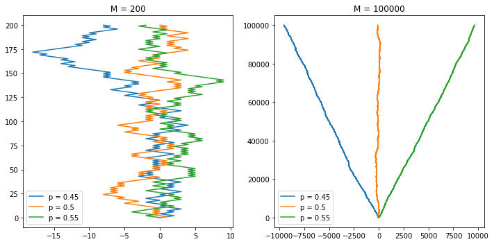

```python
import matplotlib.pyplot as plt

def lag_plot(P, M, Dx): # definerer en funksjon for å plotte inn en vandrer med en bestemt p_r verdi
    x = np.zeros(M)
    t = np.zeros(M)
    for i in P:
        x, t = en_endimensjonal_vandrer(M, i, Dx)
        plt.plot(x, t, label = f'p = {i}')
        if M > 1000:
            print("Sluttposisjon til vandrer med p_r", i, ":", x[-1])
    plt.legend()
    return x, t

P = [0.45, 0.5, 0.55] # array med henholdvis verdiene til p_r
Dx = 1

# Endrer størrelsen på figuren for å se enklere på detaljene
plt.figure(figsize=(10,5))

# Plotter for tilsvarende M = 200 og M = 100000 i en figur. Det blir dermed mulig å se hvordan M påvirker grafen
plt.subplot(1,2,1)
lag_plot(P, 200, Dx)
plt.title("M = 200")

plt.subplot(1,2,2)
lag_plot(P, 100000, Dx)
plt.title("M = 100000")

plt.tight_layout()
plt.show()
```

Om man kjører koden over, vil man få to plott av tre virrevandrerere som beveger seg langs x-aksen plottet mot tid oppover langs y-aksen. Hver av de tre vandrerne er assosiert med hver sin sansynlighet for å gå mot høyre. I plottet til venstre har vi latt funkjsonen fra oppgave b) kjøre med antall steg $M=200$. Dette er stort nok til å kunne ane i hvilken retning de tre vandrerne foretrekker å gå, men med regelmessig unntak hvor for eksempel "høyre" sti ender til venstre for en av de andre. Dette er på grunn av den tilfeldige faktoren som er inne i bildet, som ved 200 skritt ikke rekker å bli statistisk totalt overkjørt. Prøv å kjør koden et par ganger, så blir dette tydelig. Om man setter M mye høyere, forsvinner dette nesten helt.

I plottet til høyre har vi latt anntall steg M være lik 100 000. Om man setter M mye høyere, som for eksempel 1 000 000, så vil den relative variansen synke med sluttposisjonen. Merk at for høyere M vil programmet ta lengre tid før de returnener grafen.

Ved å bruke statistikk kan vi vise at for M = 100 000 og p_r = 0,55 så skal 55% av antall steg gå til høyre og (100%-55%) mot venstre. Det vil si at at en vandrer med p_r = 0,55 vil i gjennomsnitt ta 55 000 steg til høyre og 45 000 steg til venstre. Ved å ta en kumulativ sum av disse vil sluttposisjon til en vandrer være på x = 10000. Vi ser at sluttposisjonem for vandreren ligger på 10000 med en relativ variasjon på 10% , som er nærme nok for at statistikken stemmer.

### d) N 1-dimensjonale vandrere

```
<function matplotlib.pyplot.show(close=None, block=None)>
```

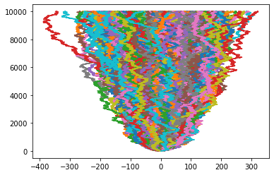

```python
def n_endimensjonale_vandrere(N, M, p_r, Dx): # definerer funskjon med argumentene for antall vandrere og hvor mange steg de skal gå gjennom.
    x = np.zeros((N, M+1))
    t = np.linspace(0, M, M+1)

# På samme måte som i oppgave b må vi ha tilfeldige tall som avgjør om vandrere skal til venster eller høyre. I dette tilfellet må vi lage matrise med N rad og M kolonner.
    virring = np.random.rand(N, M)
    trufal_matrise = (virring > p_r)

# Her må vi itere i tillegg for hver vandrer, noe som gjør koden n ganger tregere enn for bare en vandrer. Videre har vi optimalisert koden for at den går raskere.
    for i in range(N):
        for j in range(M):
            if trufal_matrise[i][j]:
                x[i][j+1] = x[i][j] + Dx
            else:
                x[i][j+1] = x[i][j] - Dx

    return x, t

N= 1000
M = 10000
p_r = 0.5
Dx = 1

x, t = n_endimensjonale_vandrere(N, M, p_r, Dx)
# Plotter hver vandrer i grafen
for k in x:
    plt.plot(k, t)
plt.show
```

### e) Tidsoptimering

Under kjører den uendrede koden fra cellen over, mens tiden blir tatt for å se hvor rask den originale koden er, før vi forbedrer kjøretiden i cellen nedenfor.

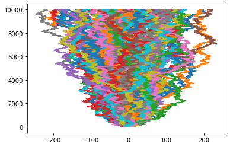

```
Antall sekunder det tok for å kjøre første funksjon: 0.5887978076934814
Antall sekunder det tok for å kjøre andre funksjon: 0.5982041358947754
Tidsforskjell mellom første og andre funksjon: -0.009406328201293945
```

```python
# Dette er en forbedring av funksjonen for n_endimensjonale_vandrere. Originialfunksjonen bruker en for-løkke for å iterere gjennom hver tidsteg for hver vandrer. Her brukes istedenfor numpy
# funksjonen numpy.cumsum for å summere over alle steg for hver vandrer i en kolonne.
def n_endimensjonale_vandrere_optimal(N, M, p_r, Dx): # Dx er distansen en vandrer plasserer etter et tidssteg
    t = np.linspace(0, M-1, M)
    random_matrise = np.random.rand(N, M)
    x = np.cumsum((random_matrise > p_r) * 2 * Dx - Dx, axis=1)
    # For (random_matrise > p_r) returnerer den True eller False. True tilsvarer tallet 1, så ganget med 2 * Dx har en vandrer beveget seg 2 ganger til høyre. Til slutt substraerer mann en Dx
    # for at netto plassering blir 1 Dx. Dersom betingelsen returnerer false, vil tallet den returnerer være 0. 0 substraert med 1 Dx tilsvarer et steg til venstre.

    return x, t

N = 100
M = 10000
p_r = 0.5
Dx = 1
x, t = n_endimensjonale_vandrere_optimal(N, M, p_r, Dx)
for k in x:
    plt.plot(k, t)
plt.show()

# Beregner tiden det tar for å kjøre hver funksjon og printer den ut
tid_ikke_optimalisert = time.time()
x, t = n_endimensjonale_vandrere(N, M, p_r, Dx)
tid_a = (time.time() - tid_ikke_optimalisert)
print("Antall sekunder det tok for å kjøre første funksjon:", tid_a)

tid_optimalisert = time.time()
x, t = n_endimensjonale_vandrere(N, M, p_r, Dx)
tid_b = (time.time() - tid_optimalisert)
print("Antall sekunder det tok for å kjøre andre funksjon:", tid_b)

print("Tidsforskjell mellom første og andre funksjon:", tid_a-tid_b)
```

I kodeplokken over blir tiden funksjonen n_endimensjonale_vandrere bruker på å kjøre tatt, som tar en del tid i seg selv. Over har vi laget en versjon som er forbedret med tanke på kjøretid.

Koden over viser en oppdatert versjon av n_endimensjonal_vandrer, hvor vi har endret måten den regner ut posisjonen til hver vandrer. Etter man definerer funksjonen, ser man hvor lang tid det tar for datamaskinen å returnere resulatene og observerer den i forhold til n_endimensjonal_vandrer.

### f) Empirisk varians

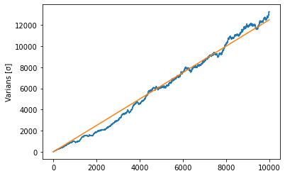

```
Stigningstallet er lik [1.24879289], ifølge scipy.optimize_curve
```

```python
from scipy.optimize import curve_fit

M = 100
N = 10000
Dx = 1
p_r = 0.5

x, t = n_endimensjonale_vandrere(M, N, p_r, Dx)
x_var_empirical = np.zeros(M)
x_var_empirical = np.var(x, axis=0, ddof=1) #en vektor med tall av variansen
def func(t, a):  # Den ideelle funskjon
    return a*t

plt.plot(t, x_var_empirical)
plt.plot(t, func(t, curve_fit(func, t, x_var_empirical)[0]))
plt.ylabel("Varians [σ]")
plt.show()

print(f"Stigningstallet er lik {curve_fit(func, t, x_var_empirical)[0]}, ifølge scipy.optimize_curve")
```

Det er lettere å se sammsvaret med oppgave 1a) om man øker M får man mere data, så støy blir overdøvet og linjen vises tydeligere. Større N tar vi inn flere vannmolekyler som fører til mindre varians i datapunktene (per definisjon varians).

### g) Todimensjonale virrere

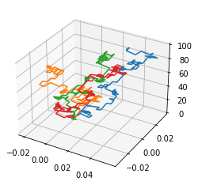

```python
def n_todimensjonale_vandrere(N, M, Dx):
    posisjon_x = np.zeros((N,M))
    posisjon_y = np.zeros((N,M))
    t = np.linspace(0, M, M)

    virring = np.random.rand(N, M)
    verthori = np.random.rand(N, M)  # Lager en matrise av tilfeldige tall som bestemmer om vandreren flytter på seg horisontalt eller vertikalt

    for i in range(N):
        for j in range(M-1):
            if verthori[i][j] > 0.5:
                if virring[i][j] > 0.5:
                    posisjon_x[i][j+1] = posisjon_x[i][j] + Dx
                    posisjon_y[i][j+1] = posisjon_y[i][j]
                else:
                    posisjon_x[i][j+1] = posisjon_x[i][j] - Dx
                    posisjon_y[i][j+1] = posisjon_y[i][j]

            else:
                if virring[i][j] > 0.5:
                    posisjon_x[i][j+1] = posisjon_x[i][j]
                    posisjon_y[i][j+1] = posisjon_y[i][j] + Dx
                else:
                    posisjon_x[i][j+1] = posisjon_x[i][j]
                    posisjon_y[i][j+1] = posisjon_y[i][j] - Dx



    return posisjon_x, posisjon_y, t


N = 4
M = 100

posisjon_x, posisjon_y, t = n_todimensjonale_vandrere(N, M, 0.004)

coord = plt.figure().add_subplot(projection='3d')
for l in range(N):
    coord.plot(posisjon_x[l], posisjon_y[l], t)
plt.show()
```

### h) Analytisk løsning av $P(x=0, t=1)$ og $P(x=0, t=2)$ for virrevandrer i henholdsvis én og to dimensjoner

$P(x=0, t)$ er sansynligheten for at en virrevandrer returnerer til origo minst en gang i løpet av tiden t. Da er $P(x=0, t=1)$ i én dimensjon sansynligheten for at en vandrer langs en snor returnerer til origo etter ett tidssteg. Siden vandreren må gå enten til høyre eller til venstre fra origo i det første tidssteget, er det ingen mulighet for at den kan ende tilbake innen $t=1$. Det er umulig at den returnerer til origo for alle odde tidssteg $\newline\quad \Rightarrow \quad 1D: P(x=0, t=1) = 0 $.

$P(x=0, t=2)$ for en todimensjonal vandrer er sansynligheten for at en vandrer returnerer til orgigo innen tidssteg to. I første tissteg kan vandreren gå én av fire veier, alle med lik sansynlighet. I andre tidssteg har den også fire valg, hvorav ett returnerer den til origo. Antall gunstige er da 4, og antall mulige er de fire første stegene i $t=1$ ganger de fire mulige stegene fra hver av de fire tillatte posisjonene i $t=1$: $$ \Rightarrow \quad P(x=0, t=2) = \frac{antall \;gunstige}{antall\;mulige} = \frac{4 \cdot 1}{4 \cdot 4} = \frac{1}{4}$$

### i) P(x=0, t mot uendelig)

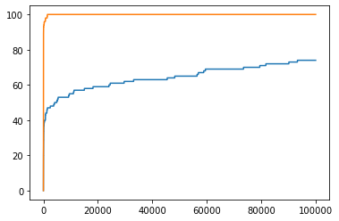

```python
# Denne funksjon returnerer en graf med N antall vandrere som har krysset origo minst en gang i løpet av M antall steg
def origo(N, M, dimensjon): # Dimensjon bestemmer om vi skal regne for 1-dimensjonale vandrere eller for 2-dimensjonale vandrere
    if dimensjon == 1:

        # Henter fram funksjonen for 1-dimensjonale vandrere. Merk at vi transponerer matrisen for å få den posisjonen til alle på første rad ved M = 0
        # deretter fjerner man den fra matrisen, ellers vil funksjonen gjenkjenne M = 0 som første gangen alle vandrere krysser origo, fordi alle vandrere starter på origo.
        x, t_array = n_endimensjonale_vandrere(N, M, 0.5, 1)
        x = x.T
        x = np.delete(x, 0, axis=0)
        x = x.T
        counter = 0 # denne skal telle antall vandrer som har plassert origo

        data_array = np.array([])
        for i in range(0, N):
            x_boolean = x[i] == 0 # returnerer en True/False array hvor en vandrer har plassert origo (x = 0)
            try:
                res = next(o for o, val in enumerate(x_boolean) if val == True) # prøver å returnere indexen hvor vandrer har plassert origo, hvis den ikke finner indexen, returnerer den 0
            except StopIteration:
                res = 0
            data_array = np.append(data_array, res) # setter res verdien i en liste. Denne lista inneholder indexer hvor hver vandrer har plassert origo for første gang


        x_array = np.array([0], dtype=float) # denne array skal vise antall vandrere som har plassert origo for hver tidssteg
        for j in range(1, M+1):
            for k in range(N):
                if data_array[k] == j:
                    counter += 1

            x_array = np.append(x_array, ((counter/N)* 100))


        plt.plot(t_array, x_array) # plott inn og vis frem
        plt.show()

    # for andre dimensjon er metoden lignende, men nå må vi sjekke for hvor x = 0 og y = 0 ved samme tidssteg
    if dimensjon == 2:
        x, y, t = n_todimensjonale_vandrere(N, M, 1)

        x = x.T
        x = np.delete(x, 0, axis=0)
        x = x.T

        y = y.T
        y = np.delete(y, 0, axis=0)
        y = y.T

        origo_array = np.zeros(N)

        counter = 0

        for i in range(0, N):
            x_test = x[i]
            y_test = y[i]
            for g_1 in range(0, M-1):
                if x_test[g_1] == 0 and y_test[g_1] == 0: # if statement som sjekker hvis x = 0 og y = 0 for den vandreren. Hvis true så legger man indexen i origo_array og sjekker for neste vandrer
                    origo_array[i] = g_1
                    continue

        origo_array = np.sort(origo_array) # sorterer arrayen fra første indexer til siste. Dette ble gjort for å debugge koden

        thecounter = 0 # Likt som for en-dimensjons tilfellen, lager vi en counter som teller antall vandrer som har plassert origo minst en gang og legger det inn i en array for hver iterasjon
        antall_ganger = np.zeros(M)

        for gag in range(1, M):
            for geg in range(N):
                if origo_array[geg] == gag:
                    thecounter += 1
            antall_ganger[gag] = (thecounter/N) * 100

        t_array = np.linspace(0, M, M) # lager en array for hver tidssteg.

        # Plotter arrayen for antall vandrer som har plassert origo med tid array
        plt.plot(t_array, antall_ganger)
        plt.show


origo(100, 100000, 2)
origo(100, 100000, 1)
```

Linjen markert med oransje viser antall vandrere som passerer gjennom origo minst en gang som funksjon av antall steg. Den blå linjen viser for 2-dimensjons vandrere. Vi observerer at for 1-dimensjons tilfellet vil den konvergere raskt mot antall vandrere. Dette stemmer overens med den analytiske sannsyligheten for enhver vandrer som passerer gjennom origo minst en gang. Merk at i den numeriske løsningen kan vi ikke bestemme tiden til å gå mot uendelig, så for å tilfredsstille problemet har vi valgt å velge M stort nok for at beregningene ikke bruker lang tid. Dette gjør allikevel at for 2-dimensjon tilfellet ikke stemmer med den analytiske løsningen. Allikevel, om vi øker M nok, vil vi se etterhvert at funksjonen konvergerer sakte mot antallet vandrere. Datamaskinen vi brukte tok cirka 24 sekunder for å plotte inn grafen med M = 100 000, så hvis man setter inn M = 1 000 000, vil det cirka ta over 240 sekunder for å få fram grafen.

Når man øker antall N, blir grafen "glattere" som funksjon av M. Den vil særdeles vise fram en mer representativ form for den isentropiske bevegelsen til virrevandrere. Dermed hvis M er en relativ størrelsesorden 10^3 større enn N, vil grafen peke mot et mer pålitelig resultat, som ikke avhenger av tilfeldighet.

## Oppgave 2 Diffusjon av vannmolekyler i hjernen

### a) Diffusjon i friskt vev

```python
import numpy as np
import matplotlib.pyplot as plt
# Dette for å kunne restarte kernel uten å måtte kjøre hele oppgave 1.
```

```python
Dx = 0.004
Dt = 0.01
```

La $\Delta x = 0,004 \; \textrm{mm} \;$ og $\Delta t = 0,01\;\textrm{s}$, da er diffusjonskonstanten $D = \frac{(\Delta x)^2}{2\Delta t} = \frac{(0,004\;\textrm{mm})^2}{2\cdot 0,01\;\textrm{s}} = 0,0008\;\textrm{mm}^2\;\textrm{s}^{-1} $ i friskt vev.

### b) Diffusjon i vev med tumorer

Under er kode for å regne ut diffusjonskonsanten i 2D-rommet vårt. Dette blir omgivelsene vandrerne skal bevege seg gjennom, og skal etterligne en hjerne med tumorer som vandrerne kan bevege seg gjennom.

```python
def diffusjon(A, tumorer, t_k, L, size):
    Dx_matrix = np.full((size, size), 0.004)                        # Genererer en matrise med Dx verdier, her fylt med friskt vev.
    sentrum_matrix = np.random.uniform(-L/2, L/2, [tumorer, 2])     # Genererer sentrene til tumorer
    twoDspace = np.linspace(-L/2, L/2, size)                        # Deler boksen med lengde L inn size mange deler
    xv, yv = np.meshgrid(twoDspace, twoDspace)                      # Lager et mesh-grid av linspacet som blir "oppløsningen til hjernen"
    r = np.sqrt(A/np.pi)                                            # Regner ut radien til sentrene

    for i in range(len(sentrum_matrix)):
        Dx_matrix = np.where((xv-sentrum_matrix[i][0])**2 + (-yv-sentrum_matrix[i][1])**2 > r[i]**2 , Dx_matrix, Dx_matrix*np.sqrt(t_k[i]))
        # En for-loop som endrer Dx-verdien i de punktene som er på innsiden av en tumor.
    return Dx_matrix
```

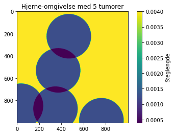

```python
tumorer = 5
A = np.pi*(Dx)**2 * np.full(tumorer, 1)
t_k = np.full(tumorer, 0.1)

Dx_matrix = diffusjon(A, tumorer, t_k, 0.02, 1000)
plt.imshow(Dx_matrix)
plt.colorbar(label='Steglengde')
plt.title(f"Hjerne-omgivelse med {tumorer} tumorer")
plt.show()
```

Plottet over visualiserer Dx_matrisens verdier og viser tydelig de sirkulære tumorene hvor steglengden $\Delta x$ er redusert, avhengig av hvor mange tumorer som overlapper.

Funksjonen np.where er definert litt uintuitivt, legg merke til retningen til ulikhetstegnet i argumentet i koden. yv er også negativ i argumentet til where-funksjonen. Dette er fordi vi vil starte i rad 1 og kolonne 1 i både xv- og yv-matrisen. Siden yv-matrisen genereres fra linspacet fra -L/2, vil yv-koordinatene starte med negative verdier, men vi er interresert i de motsatte. Å bare skifte fortegn på yv fikser dette, ellers blir sentrene speilet over y-aksen. Noe som egentlig ikke gjør at noe går galt, men det er fint å faktisk jobbe med en funksjon som gjør akkurat det intensjonen var.

Vi har valgt å endre på parameterne diffusjon() tar inn. Dette så det bare er de variablene vi faktisk ønsker å kunne definere i hver deloppgave. For eksempel ber oppgaveteksten om en funksjon som tar inn koordinater til sentrene til tumorene, men da dette bare er noe som skal brukes til å generere den effektive $\Delta x$ i gridspacet, er det mest hensiktsmessig å la funksjonen ta seg av genereringen, og bare importere de størrelsene som trengs for å lage sentrene, som anntall tumorer, deres areal, rammen L de skal genereres innenfor, i hvor stor grad de skal bremse vandrerne - t_k -, og med hvor stor oppløsning disse omgivelsene skal genereres - size. Vi endte da med en funksjon som tar inn arealet til tumorene, antall tumorer, reduksjonskoeffisienten $t_k$, dimensjonene til simuleringen L og rommets oppløsning size, som er de relevante variablene vi justerer på i senere deloppgaver.

### c) 2 Vandrere gjennom tumorer

Under er kode for å simulere to virrevandrere gå 1000 skritt gjennom tumor-omgivelsene vi definerte i kodecellen over. Den første cellen her definerer noen konstanter som brukes i simuleringen, og den andre cellen er en utvidelse av n_todimensjonale_vandrere() fra oppgave 1g) hvor vi tar inn en varierende steglengde fra Dx_matrisen kodecellen over returnerer.

```python
N = 2
M = 1000

size = 1000         # Gridspace-oppløsningen, obs: Den ***må være odde***. Dette er så origo faktisk er i midten av Lx og Ly.
if size % 2 == 0:
    size += 1       # Kode som brute forcer size til å bli odde i tilfelle noen skulle være så uheldig å oppgi et partall.

tumorer = 15
L = 0.02            # i mm
A = np.pi*(Dx)**2 * np.full(tumorer, 1)
t_k = np.full(tumorer, 0.1)
        # Her er t_k og arealene en liste med størrelsen lik antall sentrumspunkt da funksjonen diffusjon() tar inn t_k som
        # liste. Dette er for å senere kunne operere med tumorer med forskjellig diffusjonskonstant.
```

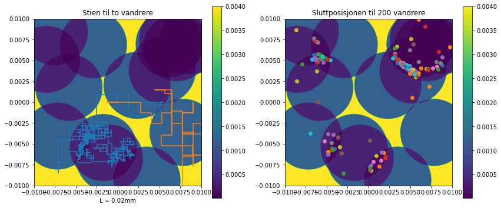

```python
def finn_nærmeste_punkt(liste, verdi):
    indeks = (np.abs(liste - ((verdi*size)/L))).argmin()
    return liste[indeks]
    # En funksjon som finner det nærmeste punktet til en verdi i en liste.

def n_todimensjonale_vandrere_i_tumor(Dx_matrix, L, size):

    posisjon_x = np.zeros((N,M))
    posisjon_y = np.zeros((N,M))
    t = np.linspace(0, M, M)
    # Lager tomme posisjonsmatriser for N vandrere med M tidssteg i x- og y-retning

    avstand_origo = np.linspace(-(size-1)/2, (size-1)/2, size)
    # Lager en array med dimmensjonene til gridspacet i oppgaven over, men i heltall. Dette for å få slice Dx_matrix, slik at vi får hentet ut
    # rett verdi for Dx i posisjonen til vandreren.

    virring = np.random.rand(N, M)
    verthori = np.random.rand(N, M)
    # Lager tilfeldige tall for valg av virreretning

    for i in range(N):
        for j in range(M-1):
            if verthori[i][j] > 0.5:
                if virring[i][j] > 0.5:
                    posisjon_x[i][j+1] = posisjon_x[i][j] + Dx_matrix[-int(finn_nærmeste_punkt(avstand_origo, posisjon_y[i][j]) + (size-1)/2)][int(finn_nærmeste_punkt(avstand_origo, posisjon_x[i][j]) + (size-1)/2)]
                    posisjon_y[i][j+1] = posisjon_y[i][j]
                else:
                    posisjon_x[i][j+1] = posisjon_x[i][j] - Dx_matrix[-int(finn_nærmeste_punkt(avstand_origo, posisjon_y[i][j]) + (size-1)/2)][int(finn_nærmeste_punkt(avstand_origo, posisjon_x[i][j]) + (size-1)/2)]
                    posisjon_y[i][j+1] = posisjon_y[i][j]

            else:
                if virring[i][j] > 0.5:
                    posisjon_x[i][j+1] = posisjon_x[i][j]
                    posisjon_y[i][j+1] = posisjon_y[i][j] + Dx_matrix[-int(finn_nærmeste_punkt(avstand_origo, posisjon_y[i][j]) + (size-1)/2)][int(finn_nærmeste_punkt(avstand_origo, posisjon_x[i][j]) + (size-1)/2)]
                else:
                    posisjon_x[i][j+1] = posisjon_x[i][j]
                    posisjon_y[i][j+1] = posisjon_y[i][j] - Dx_matrix[-int(finn_nærmeste_punkt(avstand_origo, posisjon_y[i][j]) + (size-1)/2)][int(finn_nærmeste_punkt(avstand_origo, posisjon_x[i][j]) + (size-1)/2)]
    return posisjon_x, posisjon_y, t

Dx_matrix = diffusjon(A, tumorer, t_k, L, size)
x, y, t = n_todimensjonale_vandrere_i_tumor(Dx_matrix, L, size)

fig = plt.figure(figsize=(14, 6))
ax1 = fig.add_subplot(121)
for i in range(len(x)):
    ax1.plot(x[i], y[i])
plt.imshow(Dx_matrix, extent=[-L/2, L/2, -L/2, L/2])
ax1.set_title("Stien til to vandrere")
ax1.set_xlabel(f'L = {L}mm')
plt.colorbar()


ax2 = fig.add_subplot(122)
for i in range(100):
    x, y, t = n_todimensjonale_vandrere_i_tumor(Dx_matrix, L, size)
    for i in range(len(x)):
        ax2.plot(x[i][-1], y[i][-1], 'o')
plt.imshow(Dx_matrix, extent=[-L/2, L/2, -L/2, L/2])
ax2.set_title("Sluttposisjonen til 200 vandrere")
ax1.set_xlabel(f'L = {L}mm')
plt.colorbar()

plt.show()
```

Måten vandrerne oppdaterer skrittlengden sin i denne tilnærmingen er at de før de går sjekker om de er på innsiden eller på utsiden av en tumor, og så henter ut riktid skrittlengde $\Delta x$. Dette gjør at om en vandrer går på langs kanten av en tumor og snitter den fra utsiden slik at den startet i friskt vev, og endte i friskt vev gjennom ett skritt, så vil den ikke legge merke til at den har gått gjennom en tumor. Det er bare en svakhet med koden vi må svelge med vår tilnærming med Dx_matrix som et distretisert mesh-grid av hjerne-omgivelsene. Ved å sørge for at M er tilstrekkelig stor vil alle punkter fremdeles bli besøkt tilstrekkelig, slik vi viste i oppgave 1i) (skrittlengden er ikke diskret selv om Dx_matrix er det). Senere implementerer vi også preiodiske grensebetingelser, som bidrar til at alt vev, sykt og friskt, blir besøkt rigorøst. Det er imidlertid fremdeles en svakhet, og det er veldig småe tumorer, altsp i størrelsesorden 'en del mindre enn $\Delta x$ i friskt vev'. Hvis en slilk tumor er plassert som en liten øy omgitt av friskt vev er det mulig at den aldri blir besøkt ordentlig, da de flese vandrerne bare vil gå gjennom den, og en vandrer må ende opp inne i tumoren for at det skal registreres. Om en vandrer skulle ende på innsiden, er det fremdeles bare én tumors $t_k$ som vil påvirke steglengden. Siden tumoren allerede mye mindre enn skrittlengden, vil en litt mindre skrittlengde ikke hidre vandreren å raskt komme seg ut igjen, nå i en anne possisjon i forhold til tumoren, slik at det igjen er svært liten sansynlighet for at tumoren besøkes av samme vandrer. Denne svakheten skylles altså at vandrerne bare endrer skrittlengden til den posisjoen de har landet i, ikke alle posisjonene de beveger seg gjennom. Det er synlig lenger nede i prosjektet, i oppgave 2f), der både hjerneomgivelsene og intensiteten plottes sammen, og hvor tumorene har tilfeldig størrelser. Om det genereres en bitteliten tumor vil den nesten aldri fukke opp i intensitetsbildet, og MRI-simuleringen vil ikke kunne avbilde den.

Dx_matrix[int(finn_nærmeste_punkt(avstand_origo, posisjon_y[i][j]) + (size-1)/2)][int(finn_nærmeste_punkt(avstand_origo, posisjon_x[i][j]) + (size-1)/2)]

Koden over er ganske vanskelig å lese, derfor spanderer jeg en hel celle for å forklare hva som skjer her. Dx_matrix er matrisen med de effektive $\Delta x$-verdiene i tumor-omgivelsene, alle fordelt i mesh-griddet Dx_matrix hvor tumorene er plasser. Vandrerne kan imidlertid bevege seg uavhengig av dette griddet, men de skal ta steglengder avhengig av hvor de er i forhold til mesh-griddet. Det denne koden skal gjøre er å hente ut riktig skrittavtand fra matrisen når vandreren skal flytte på seg, altså å oversette posisjonen til vandreren i avstand fra origo til mesh-griddets tumor-omgivelser.

Når vandreren er i origo korresponderer dette til $\Delta x$-verdien til det midterste tallet i matrisen. Første slize i linjen over er for å hente ut radvektoren vandreren befinner seg i den korresponderende posisjonen i mesh-griddet. Den andre slicen er for å finne hvilken indeks i raden - hvilken kolonne - vandreren befinner seg i. I en matrise med dimensjoner $size \times size$ fra $-L < 0 < L$ finner man $y=0$ i listen $\frac{size-1}{2}$. Det er viktig at size er odde, ellers finnes det ikke et symetrisk origo. Deretter må man finne matriseelementet til Dx_matrix som korresponderr til origo, som er det midterste elementet, altså det $\frac{size-1}{2}$-elementet i listen. Origo til vandrerne tilsvarer da disse to slizene i Dx_matrix. Dermed er den korresponderende posisjonen til vandreren i mesh-griddet denne avstanden fra origo $+ \frac{size-1}{2}$. Dette blir da regnet ut først for y-, så for x-aksen i slizingen.

I tillegg bruker vi funksjonen finn_nærmeste_punkt() som tar inn en liste og en tallverdi, og returnerer det nærmeste punktet i lista. Dette trengs, da posisjonen til vandreren kommer til å være mellom punktene i meshgriddet siden skrittlengden ikke er konstant. Denne funksjone assosierer da posisjonen til vandreren til nærmeste korrelerende punkt i mesh-griddet. Listen svstand_origo er et linspace med size anntal stem fra $-\frac{size-1}{2}$ til $\frac{size-1}{2}$. Denne bruker vi sammen med posisjonen til vandreren for å finne anstand den har fra origo. Dette plus leddet $\frac{size-1}{2}$, så int over alt sammen gir det heltallet som henter rett rad, så kolonne, for å assosiere possisjonen til vandreren til den rette verdien i Dx_matrisen.

Koden kunne definitivt vært mer elegant, men den funker. En enkel forbedring som enda bruker samme idé er å endre funksjonen finn_nærmeste_punkt() til å ikke bare returnere nermeste nærmeste avstand fra origo, men gjør hele jobben og returnerer det eksakte heltallet Dx_matrix trenger for å slize rett. Eventuelt endre måten posisjonen til vandreren håndteres slik at den er lettere å regne om til mesh-griddet, men da måtte vi ha gjort mye av koden til 2D-vandrerne fra tidligere. Vi har heller valgt å bruke den vi lagde underveis med modifikasjoner. Siden vi per da ikke viste hvike egenskaper koden burde ha er den ikke perfekt for formålet i de senere deloppgavene i oppgave 2, men de kjører. Mer kunnskap i numerisk lineær algrbra hadde definitivt også kommet godt med, men så langt er vi ikke kommet i faget..

### d) Grensebetingelser

Vi velger periodiske grenser som grensebetingelser for denne simuleringen. Dette er fordi det vi simulerer er en liten del av en større hjerne, hvor det vil være flyt inn og ut av virrede vannmolekyl fra omgivelsene vi ikke ser på. Med for eksempel harde vegger hadde man heller simulert innsiden av en celle eller en hel hjerne, hvor det ikke er, eller er svært begrenset med flyt av vannmolekyler inn og ut. Vi ser på et lite snitt av hjernen med sidekanter L. Når et vannmolekyl - en virrevandrer - går ut av omgivelsene våre, og kommer inn på den andre siden, vil dette etterligne et system hvor vannmolekylene er frie til å komme og gå, med konstant netto fluks av vannmolekyler inn og ut. Man kan også argumentere for at det å la være å lage grensebetingelser kan være en god løsning om grenseflatene er så store at det ikke kommer seg ut, men en simulering av vannmolekyl i hjernen vil først begynne å bli en god tilnærming når vandrerne er nogenlunde homogent fordelt. Dette skjer først når flaten vår begynner å fylles av vandrere. For å faktisk simulere et lite stykke av et større system trenger vi da at det fylles etter med vandrere når andre vandrere "forlater" grensene. Ellers blir hjernestykket som blir simulert, sakte drenert for vann mens virrerne sprer seg, noe som ikke ligner oppførselen til vann i vev når $t \rightarrow \infty$, noe som med $L = 0.02$ mm og skrittlengde på $0.004$ mm tar 5 skritt, og derfor vil skje svært raskt.

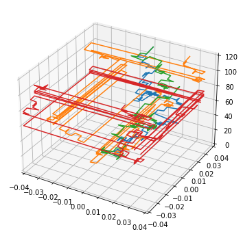

```python
M = 120
N = 4
L = 0.08
tumorer = 0
# Her er noen konstanter justert for bedre å visualisere grensebetingelsene som introduseres. Tumorene er ikke viktige i denne deloppgaven, så
# de vil bare gi mindre forutsigbarhet i vandrernes virre-lengde. Her skal noen vandrere nå grensene. Gjør de ikke det, så kjør koden på nytt.

def finn_nærmeste_punkt(liste, verdi):
    indeks = (np.abs(liste - ((verdi*size)/L))).argmin()
    return liste[indeks]

def n_todimensjonale_vandrere_med_grenser(Dx_matrix, L, size):
    posisjon_x = np.zeros((N,M))
    posisjon_y = np.zeros((N,M))
    t = np.linspace(0, M, M)
    avstand_origo = np.linspace(-(size-1)/2, (size-1)/2, size)
    virring = np.random.rand(N, M)
    verthori = np.random.rand(N, M)

    for i in range(N):
        for j in range(M-1):
            if verthori[i][j] > 0.5:
                if virring[i][j] > 0.5:
                    posisjon_x[i][j+1] = posisjon_x[i][j] + Dx_matrix[-int(finn_nærmeste_punkt(avstand_origo, posisjon_y[i][j]) + (size-1)/2)][int(finn_nærmeste_punkt(avstand_origo, posisjon_x[i][j]) + (size-1)/2)]
                    posisjon_y[i][j+1] = posisjon_y[i][j]
                    if posisjon_x[i][j+1] >= L/2:
                        posisjon_x[i][j+1] = posisjon_x[i][j+1] - L
                    # Her er grensebetingelsene implementert. Etter at en vandrer har gått et skritt, sjekker denne if-setningen om vandreren
                    # har bevegd seg ut av grensen L i den retningen den har bevegd seg. Om ja, "teleporteres" vandreren til den andre siden av
                    # grensa.
                else:
                    posisjon_x[i][j+1] = posisjon_x[i][j] - Dx_matrix[-int(finn_nærmeste_punkt(avstand_origo, posisjon_y[i][j]) + (size-1)/2)][int(finn_nærmeste_punkt(avstand_origo, posisjon_x[i][j]) + (size-1)/2)]
                    posisjon_y[i][j+1] = posisjon_y[i][j]
                    if posisjon_x[i][j+1] < -L/2:
                        posisjon_x[i][j+1] = posisjon_x[i][j+1] + L
            else:
                if virring[i][j] > 0.5:
                    posisjon_x[i][j+1] = posisjon_x[i][j]
                    posisjon_y[i][j+1] = posisjon_y[i][j] + Dx_matrix[-int(finn_nærmeste_punkt(avstand_origo, posisjon_y[i][j]) + (size-1)/2)][int(finn_nærmeste_punkt(avstand_origo, posisjon_x[i][j]) + (size-1)/2)]
                    if posisjon_y[i][j+1] >= L/2:
                        posisjon_y[i][j+1] = posisjon_y[i][j+1] - L
                else:
                    posisjon_x[i][j+1] = posisjon_x[i][j]
                    posisjon_y[i][j+1] = posisjon_y[i][j] - Dx_matrix[-int(finn_nærmeste_punkt(avstand_origo, posisjon_y[i][j]) + (size-1)/2)][int(finn_nærmeste_punkt(avstand_origo, posisjon_x[i][j]) + (size-1)/2)]
                    if posisjon_y[i][j+1] < -L/2:
                        posisjon_y[i][j+1] = posisjon_y[i][j+1] + L
    return posisjon_x, posisjon_y, t

Dx_matrix = diffusjon(A, tumorer, t_k, L, size)
x, y, t = n_todimensjonale_vandrere_med_grenser(Dx_matrix, L, size)

fig = plt.figure(figsize=(16, 6))
coord = fig.add_subplot(projection='3d')
for l in range(N):
    coord.plot(x[l], y[l], t)
plt.xlim(-L/2, L/2)
plt.ylim(-L/2, L/2)
plt.show()
```

I koden over er grensebetingelsene implementert i hver if-setning i den utvidede koden til virrevandreren i 2D fra oppgave 2c). if-setningene skjekker om en vandrer har kommet til, eller overskredet grensene i den aksen vandreren akkurat har flyttet seg. Hvis ja så flyttes den til den andre siden av aksen. Når dette skjer trekker plottet en strek over hele L istedet for å "teleportere" vandreren, eller tolke det som at én vandrer forlot grensen mens en ny kom inn på motsatt side, hvor sistnevnte er mest hensiktsmessige tolkning av det som skjer. Siden vandreren enda er rett ved grensen etter å ha blitt flyttet til den andre siden er sansunlygheten for at den vil gå gjennom grensen igjen derfor stor. Vi får da ofte mange linjer over plottet, og i plottet kan det se ut som at disse vandrerne ved grensene tar "mye mer plass" i datasettet enn de andre vandrerne som ikke er ved grensene. Det er ikke tilfellet, her er det bare måten plottet trekker mange lange linjer som får det til å se slik ut, husk at de egentlig bare tar korte skritt frem og tilbake som alle andre, bare at disse grensehoppernes små steg blir tegnet som lange linjer. Dette blir spesielt tydelig om en vandrer når et hjørne. Da kan den begynne å "sirkulere" hele arealet og det ser ut som at den beveger seg mye lenger selv om de bare ter små skritt ut av grensene i alle fire retninger.

Det er funksjonen n_todimensjonale_vandrere_med_grenser() fra denne deloppgaven som brukes for simuleringer av vandrere i resten av prosjektet.

### e) intensistenen I(i, j)

```python
def Intensitet(x, y, n, N, M):
    X = np.concatenate((x), axis=None)
    Y = np.concatenate((y), axis=None)
        # Lager henholdsvis en stor liste X og Y av matrisene x og y slik at de passer inn i histogram2d() fra formen x=[[1 2][3 4]] til
        # formen X=[1 2 3 4]. Da korresponderer enda X[i] og Y[i] til en possisjon til en vandrer i punktet (i, i), bare lagret i en lang liste
    H, x_edge, y_edge = np.histogram2d(X, Y, n)
    I = H/(N*M)
    return I
```

Over er koden som returnerer intensiteteten $I(i, j)$, altså anntal ganger hver posisjon $(i, j)$ er besøkt. Funkjsonen tar ikke inn variablene oppgaveteksten spør om da dette ikke er nødvendig. De variablene inngår alt i det som tas in i Intensitet(), da x og y henholdsvis er begrenset til $x_{min}, x_{makx}, y_{min},y_{makx} = \pm \frac{L_x}{2}, \pm \frac{L_y}{2}$. Videre er $n=n_n=n_y$ da matrisene vi jobber med er kvadratiske. Å definere oppløsningen til instnsitetsavbildningen som $n_x \times n_y$ i koden blir derfor rotete, da det blir flere variabler å holde styr på. Siden de uansett skal være like blir det å bruke $n$ ryddigere på alle måter.

### f) Simulering

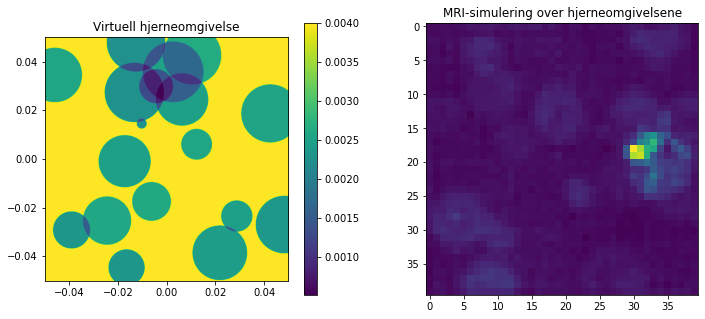

```python
M = 10000
N = 10
n = 40          # Oppløsningen til intensitestsplottet
L = 0.1

tumorer = np.random.randint(10, 25)                     # Genererer et et tilfeldig anntal tumorer mellom 10 og 25
t_k = np.random.uniform(0.3, 0.45, tumorer)             # Genererer en tilfeldog verdi for t_k for hver tumor
A = np.pi*Dx**2 * np.random.uniform(0.1, 10, tumorer)   # Genererer et tilfeldig areal for tomorene innenfor rimelige rammer

Dx_matrix = diffusjon(A, tumorer, t_k, L, size)         # Genererer Dx_matrisen
x, y, t = n_todimensjonale_vandrere_med_grenser(Dx_matrix, L, size)
I = Intensitet(x, y, n, N, M)

fig = plt.figure(figsize=(12, 5))

ax1 = fig.add_subplot(121, title='Virtuell hjerneomgivelse')
plt.imshow(Dx_matrix, extent=[-L/2, L/2, -L/2, L/2])
plt.colorbar()
ax2 = fig.add_subplot(122, title='MRI-simulering over hjerneomgivelsene')
plt.imshow(I)

plt.show()
```

Her er intensiteten, definert i deloppgave e), plottet til høyre sammen med hjerneomgivelsene fra tidligere. Nå er tumorene generert i tilfeldig kvantitet, med tilfeldig areal valgt i rimelige størrelser i forhold til grenseflatene L, og tilfeldig bremseevne av vandrerne. L er valgt til 0,1, litt større enn i tidligere deloppgaver, litt fordi det er så mange tumorer, og slik at L er tilstrekkelig mange skrittlengder lang, så sansunligheten for faktisk å komme inn i en tumor er stor nok, men ikke så stort at vandrerne ikke rekker å bevege seg mye i hele omgivelsene, noe som er nødvendig for å samle godt med data når intensitetavbildningen skal genereres. Hadde L vært for stor, hadde de trengt mye flere steg for å kartlegge omgivelsene, noe som krever kjøretid.

Når det gjelder valg av N og M, kan de være alt imellom N=1 og M så stor kjøretid tillater, og N=M, det viktigste er at M er tilstrekkelig stor for at vandrerne får gått ordentlig i omgivelsene. Jeg har inntrykk av at N=1 og M så stor kjøretiden tillater gir best resultater for oss. Med én vandrer og en million skritt får man et godt bilde, men med 1000 vandrere og 1000 skritt får vi et litt dårligere bilde for samme kjøretid. Om vi har mange vandrere, vil starten av simuleringen, når alle vandrerne er i origo samtidig, føre til støy i intensitetsavbildningen. Dette er fordi man får uproposjonalt mange besøk i origo fra starten av simuleringen. Vandrernes startposisjon kunne for eksempel velges tilfeldig innenfor grensene for å unngå dette problemet, men å la bare én vandrer vandre med dertil flere steg løser dette problemet. Kanskje dette er en del av grunnen til at simuleringer av mange vandrere blir litt dårligere for oss. Med andre ord, initialposisjonen til en enkelt vandrer har svært lite å si, men initialposisjonene, eller fordelingen av posisjonene, har mye å si når mange vandrere virrer samtidig. Derfor har vi valgt å ikke implementere en tilfeldig startposisjon, da det ikke er nødvendig med bare én vandrer. Så lenge L ikke er for stor, burde det ikke ha noe å si om man lar 1000 vandrere gå 1000 skritt, eller om man lar én vandrer gå en million skritt.

Intensiteten er et ganske godt mål på hvor tumorene ligger, men som bildene gjør tydelig, er den svært sensitiv for overlappende tumorer. Hvis det er et areal hvor det er mange tumorer som overlapper vil dette skygge over alenestående tumorer, og de vil nesten ikke synes i forhold til de lyse flekkene med mye overlapp. Det er derfor nesten ikke mulig å peke på hver enkelt tumor, men bare tumorsnittene i de tilfellene det genereres mange tumorer. Denne effekten får mindre betydning når det er mindre overlapp; intensiteten er derfor typisk en mye bedre indikator på hvor tumorene ligger når tumortallet er på den lavere siden, og sansynligheten for mye overlapp er lav. Dette er kanskje også en realistisk effekt, sansynligheten for at så mange som sju-åtte tumorer overlapper i simuleringen er helt rimelig, men i en hjerne skjer dette neppe. Ikke er jeg nevrolog, så dette vet jeg ikke mye om, men jeg vil tro at denne simuleringen svarer godt til hvordan en MRI faktisk brukes for å kartlegge svulster. I denne koden er antall tumorer imellom 10 og 25 litt i drøyeste laget for å finne dem på en god måte, når det er fem tumorer lyser det opp fem runde objekt på intensitetskartet (prøv det). Når tumorene imidlertid er i en litt mindre gunstig fordeling, som mange flere med mye overlapp, så blir det svært vanskelig å peke på en tumor. Et raskt søk på PubMed ga et resultat fra en studie, publisert i Elsevier, som skulle kartlegge feilakig negativ MRI-test for brystkreft. Det var 32 kvinner som hadde diagnostisert brystkreft som deltok, hvor alle hadde forhøyet risiko for å få brystkreft. Av de 32 hadde 23 pasienter MRI-bilder tilgjengelig, hvor fem av disse returnerte feilaktig negative (Maxwell et al., 2017). Nå er 32 subjekter svært dårlig statistikk, men i denne studien svarer dette til over 20% sansynlighet for feilaktig negativ test. Et raskt googlesøk viser at dette kan variere mye, fra 1%-20%. Selv om MRI er en svært sensitiv bildefremkallingsteknikk, vil jeg tro at sikkerheten til tumor-deteksjon med bildene er svært avhengig av at tumorene ligger gunstig til, slik vi trenger i vår simulering. Sånn som vår simulering lett kan finne snittet av flere tumorer, men kan slite med å vise hele kroppen til hver enkelt tumor der de ikke overlapper, vil jeg tro det kan være vanskelig å lage gode bilder av helheten til en ekte tumor. Hvis man for eksempel bruker dette for å rette strålebehandling mot de lysende punktene i intensitetsbildet, vil man ved et uheldig bilde bare behandle de tumorene i området de overlapper, ikke alle tumorene i deres helhet.

En svakhet til simuleringen er også hvordan vandrerne henter skrittlengden sin. De må lande inne i tumoren for at tumoren skal bremse den ned - det er ikke nok at den "glir gjennom". Dermed er ikke intensitetsavbildningen i stand til å oppdage de minste tumorene. Dette er forklart mer i detalj under oppgave 2c), der koden for å hente riktig skrittlengde ligger.

### g) Sobel-filter

```python
def sobel(I):
    gx = np.array([[1, 0, -1], [2, 0, -2], [1, 0, -1]])
    gy = np.array([[1, 2, 1], [0, 0, 0], [-1, -2, -1]])
    M, N = I.shape
    sobelx = np.zeros(I.shape)
    sobely = np.zeros(I.shape)
    Iramme = np.pad(I, (1, 1), 'constant', constant_values=(0, 0))

    for i in range(1, M-1):
        for j in range(1, N-1):
            A = Iramme[i-1:i+2, j-1:j+2]
            sobelx[i][j] = (A * gx).sum()
            sobely[i][j] = (A * gy).sum()
    sobel = np.sqrt(sobelx**2 + sobely**2)
    return sobel
```

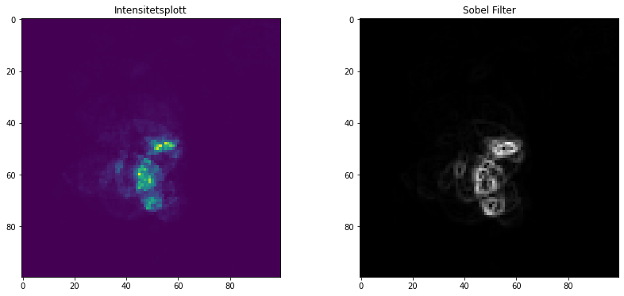

```python
M = 1000000
N = 1
n = 100
L = 0.1

tumorer = np.random.randint(10, 25)
t_k = np.random.uniform(0.3, 0.45, tumorer)
A = 5*np.pi*Dx**2 * np.random.uniform(0.1, 10, tumorer)

Dx_matrix = diffusjon(A, tumorer, t_k, L, size)
x, y, t = n_todimensjonale_vandrere_med_grenser(Dx_matrix, L, size)
I = Intensitet(x, y, n, N, M)
S = sobel(I)

fig = plt.figure(figsize=(14, 6))
ax1 = fig.add_subplot(121, title='Intensitetsplott')
plt.imshow(I)
ax2 = fig.add_subplot(122, title='Sobel Filter')
plt.imshow(S, cmap='gray')
plt.show()
```

Problemet med sobel-filteret er egentilig det samme som i oppgave 2f), nemlig at intensiteten overkjører ankeltstående tumorer om det er mange som overlapper et annet sted i omgivelsene. Ellers er sobelfilteret en god måte å finne tumorene på, så lenge man velger N og M hensiktsmessig såklart. Får ma gode data inn i Intensitet() og ikke for mange tumorer overlapper, så vil tumorene være omsluttet av en hvit linje og komme frem på en tydelig måte. Ulempen er at hver "overlapp" vil tegnes i hvitt hver for seg, ikke nødvendigvis tumorene selv. Sånn sett er det også en del støy når man skal tolke sobel-bildene såvel som intensitetsabildningene, men begge er lesbare om man vet hva informasjonen de inneholder betyr.

Når det gjelder valg av oppløsningen til intensitetsavbildningen bør den ligge på en moderat verdi, av erfaring noe mellom 30 og 100. Om den velges for liten blir bilde såpass kornete at tumorrandene blir dårlig definert, mens hvis man velger n for stor begynner den faktiske stien til vandreren å synes. Dette er uinteressant støy. I MRI ønsker vi ikke å se hvor vannmokelylene faktisk har beveget seg, men hvor de typisk opphoper seg, og for for høy oppløsning vil vise nettop dette. Det kan igjen overstyres ved å velge et dertil mye høyere antall skritt, men kjøretid er som kjent en begrensning her. Litt avhengig av hvor tumorene havner, og hvor mange de er, opplever jeg å få gode bilder med en n mellom 40 go 100. I deloppgave 2f) ser man hvordan oppløsning på n=40 gjør intensiten godt leselig, men kornete, mens i 2g) beynner man ofte å se virre-stiene med en oppløsning på n=100. Prøv å endre litt på n for å se hvordan dette påvirker bildene koden fremkaller.

### Litteratur

Maxwell, A. J., Lim, Y. Y., Hurley, E., Evans, D. G., Howell, A. & Gadde, S.(2017). False-negative MRI breast screening in high-risk women. $Elsevier$